# Assignment 6

HYUN KO

#### Due Friday, October 9, 11:59 PM

### 1

> Transform and combine the necessary data sets so that you have two rows for each zip code (one row for each sex) and the columns of data listed below. Note that you will need to eliminate the data on obesity among children, and summarize the data across age cohorts within each zip code to accomplish this task. Display the first six rows of the transformed and combined data frame using the function `head()`.

```r
obesity <- read_csv("../../data/obesity-hw.csv")
education <- read_csv("../../data/education.csv")

education <- education %>%
  rename(male = pct_m_bach, female = pct_f_bach) %>%
  pivot_longer(c("male", "female"), names_to = "sex", values_to = "pct_bach")

obesity1 <- obesity %>%
  drop_na() %>%
  filter(age != "05-17") %>%
  rename(adult_n = pop) %>%
  mutate(obese_n = adult_n * (obese / bmi)) %>%
  select(zip, sex, adult_n, obese_n) %>%
  group_by(zip, sex) %>%
  summarize(adult_n = sum(adult_n), obese_n = sum(obese_n), obese_p = (obese_n / adult_n))

result <- left_join(education, obesity1, by=c('zip', 'sex')) %>%
  select(zip, sex, adult_n, obese_n, obese_p, pct_bach) %>%
  drop_na()

head(result)
```

```
## # A tibble: 6 x 6
##     zip sex    adult_n obese_n obese_p pct_bach
##   <dbl> <chr>    <dbl>   <dbl>   <dbl>    <dbl>
## 1 53001 male       682    330.   0.483     13
## 2 53001 female     671    259.   0.386     23
## 3 53002 male      1052    404.   0.384     16.2
## 4 53002 female     977    369.   0.377     25.4
## 5 53004 male      1164    604.   0.519     23.3
## 6 53004 female    1244    553.   0.445     26.8
```

### 2

> Using the data from Question 1, we are going to investigate connections between obesity and education status (at least a bachelors degree or no bachelors degree) by sex. For this question, calculate the *estimated percentage of adults in Wisconsin who are obese* among those with at least a bachelors degree by sex. Similarly, calculate the *estimated percentage of adults in Wisconsin who are obese* among those without a bachelors degree by sex.  
> Display these values in a 2-by-2 table, i.e., a table with two rows - one for male and one for female, and two columns - one for each of the estimated percentages noted above (plus the first column sex). State any assumptions you need to make when carrying out these calculations. (Recall that you need to sum up totals of people before finding proportions.)

```r
obese_edu <- result %>%
  mutate(bach_n = adult_n * (pct_bach / 100), non_bach_n = adult_n - bach_n) %>%
  group_by(zip, sex) %>%
  summarize(total_bach_n = sum(bach_n), total_non_bach_n = sum(non_bach_n), total_n = sum(adult_n)) %>%
  mutate(obese_bach = (total_bach_n / total_n) * 100, obese_non_bach = (total_non_bach_n / total_n) * 100) %>%
  select(sex, obese_bach, obese_non_bach)

obese_edu
```

```
## # A tibble: 1,134 x 4
## # Groups:   zip [581]
##      zip sex    obese_bach obese_non_bach
##    <dbl> <chr>       <dbl>          <dbl>
##  1 53001 female       23             77.0
##  2 53001 male         13             87
##  3 53002 female       25.4           74.6
##  4 53002 male         16.2           83.8
##  5 53004 female       26.8           73.2
##  6 53004 male         23.3           76.7
##  7 53005 female       53.9           46.1
##  8 53005 male         55.6           44.4
##  9 53006 female       26.8           73.2
## 10 53006 male         15.4           84.6
## # ... with 1,124 more rows
```

### 3

> Make a scatter plot that displays the proportion of a zip code aged 25+ with a bachelor’s degree on the x-axis and the proportion obese on the y axis. Use different colors for each sex and add a trend line or curve for each sex. Create appropriate labels and titles for the plot. Comment on any apparent patterns in the data.

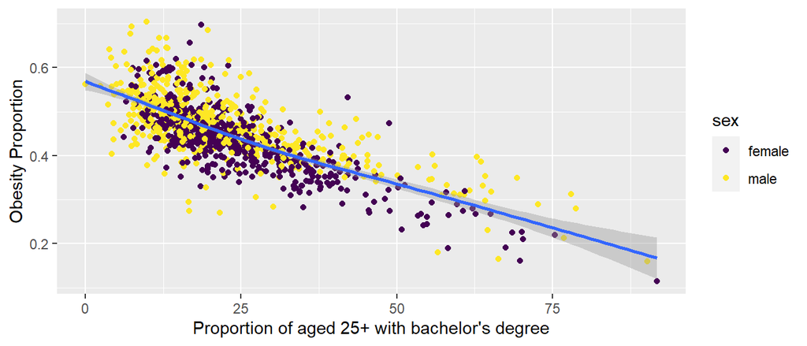

```r
ggplot(result, aes(x = pct_bach, y = obese_p)) +
  geom_point(aes(color = sex)) +
  geom_smooth() +
  xlab("Proportion of aged 25+ with bachelor's degree") +
  ylab("Obesity Proportion")
```

# The lesser people had bachelor’s degree, the higher chances of people getting obese in this data. # That is applicable to both sexes.